# Tugas Individu Minggu 7

Muhammad Farhan Adeva - G1401211062

2023-10-15

# Library

```r
library(forecast)
```

```r
library(graphics)
library(TTR)
library(TSA)
library(dplyr)
library(forecast)
library(lmtest)
library(orcutt)
library(HoRM)
library(corrplot)
library(dLagM)
library(dynlm)
library(MLmetrics)
library(ggplot2)
library(tsibble)
library(tseries)
library(MASS)
library(aTSA)
```

# Input Data

```r
library(rio)
data <- import("https://raw.githubusercontent.com/Adevaaaa/MPDW/main/Pertemuan%207/Data%20Tugas%20MPDW%201.csv")
```

# Merubah Data Menjadi Time Series

```r
data.ts <- ts(data$Suhu)
```

# Membagi data menjadi data latih (80%) dan data uji (20%) dan jadikan time series

```r
train <- data[1:115,2]
test <- data[116:144,2]
train.ts <- ts(train, frequency = 12)
test.ts <- ts(test, frequency = 12)
```

# Eksplorasi

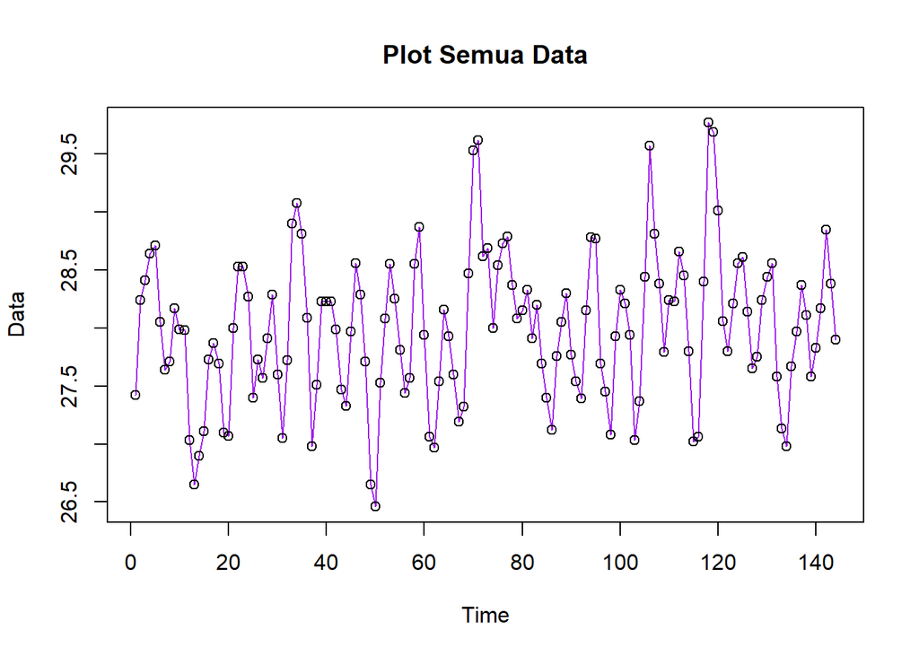

```r
# data full
ts.plot(data.ts, col="purple",main="Plot Semua Data", type="o",xlab="Time",ylab="Data")
points(data.ts)
```

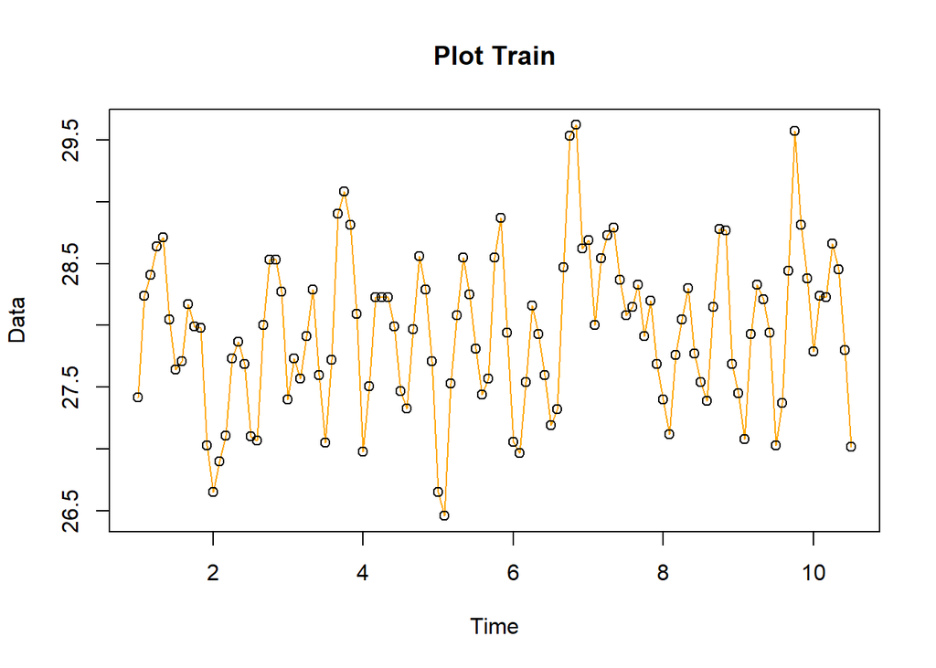

```r
# data latih
ts.plot(train.ts, col="orange",main="Plot Train", type="o",xlab="Time",ylab="Data")
points(train.ts)
```

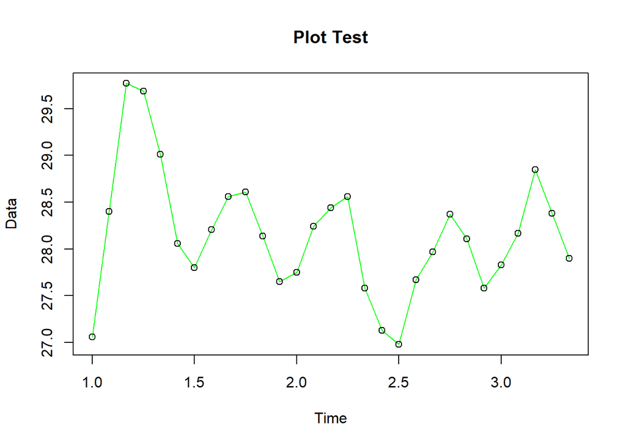

```r
# data uji
ts.plot(test.ts, col="green",main="Plot Test", type="o",xlab="Time",ylab="Data")
points(test.ts)
```

dapat dilihat bahwa data deret waktu pada suhu jakarta membentuk pola aditif musiman tanpa trend

# Check Stasioner

#Plot acf

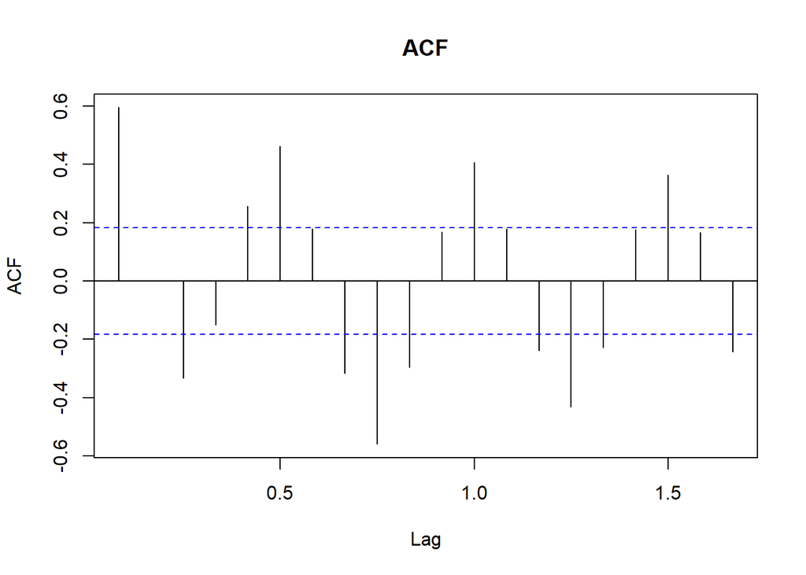

```r
acf(train.ts, main="ACF", lag.max=20)
```

#Uji ADF

```r
tseries::adf.test(train.ts)
```

```
##
##  Augmented Dickey-Fuller Test
##
## data:  train.ts
## Dickey-Fuller = -3.3377, Lag order = 4, p-value = 0.0684
## alternative hypothesis: stationary
```

$H_0$ : Data tidak stasioner dalam rataan

$H_1$ : Data stasioner dalam rataan

# Penanganan Data Tidak Stasioner dalam Rataan

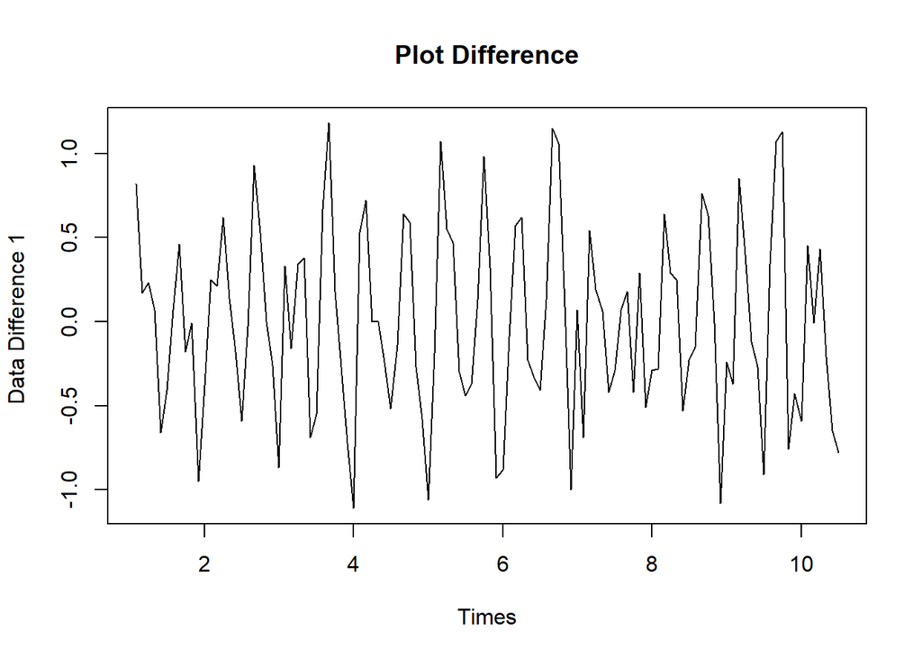

```r
train.diff<-diff(train.ts,differences = 1)
plot.ts(train.diff, lty=1, xlab="Times", ylab="Data Difference 1 ", main="Plot Difference")
```

terlihat pada plot tersebut data sudah stasioner dalam rataan ditandai dengan data bergerak pada nilai tengah.

#Plot ACF dan PACF Setelah Penanganan

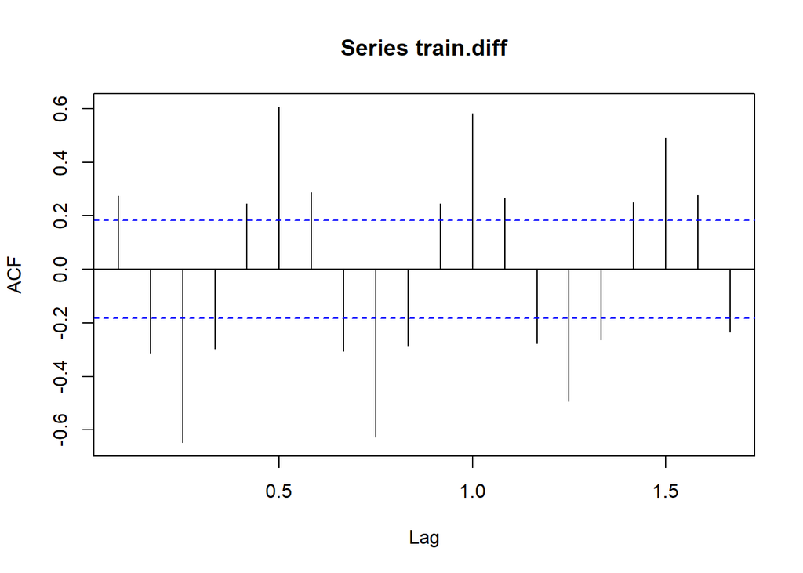

```r
acf_trainbaru <-acf(train.diff)
```

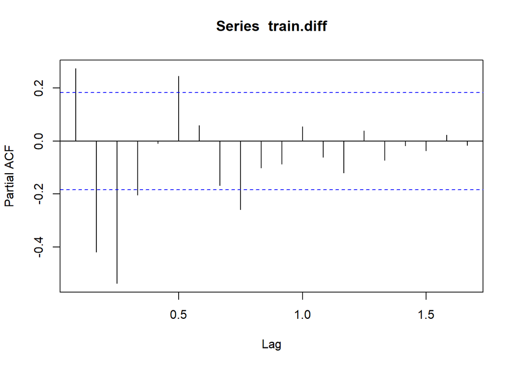

```r
pacf_trainbaru <- pacf(train.diff)
```

#Uji ADF

```r
tseries::adf.test(train.diff)
```

```
##
##  Augmented Dickey-Fuller Test
##
## data:  train.diff
## Dickey-Fuller = -7.5198, Lag order = 4, p-value = 0.01
## alternative hypothesis: stationary
```

$H_0$ : Data tidak stasioner dalam rataan

$H_1$ : Data stasioner dalam rataan

Berdasarkan uji ADF tersebut, didapat *p-value* sebesar 0.01 yang lebih kecil dari taraf nyata 5% sehingga tolak $H_0$ atau data stasioner dalam rataan. Sehingga dalam hal ini ketidakstasioneran data sudah berhasil ditangani dan dapat dilanjutkan ke pemodelan

#Plot EACF

```r
eacf(train.diff)
```

```
## AR/MA
##   0 1 2 3 4 5 6 7 8 9 10 11 12 13
## 0 x x x x x x x x x x x  x  x  x
## 1 x x x x o x x x x x o  x  x  x
## 2 x x x o o o o o o o o  o  o  o
## 3 x o x o x o o o o o o  o  o  o
## 4 x o x o o o o o o o o  o  o  o
## 5 x x o x o o o o o o o  o  o  o
## 6 x x o x o x o o o o o  o  o  o
## 7 x x o x o x o o o o o  o  o  o
```

```r
model1.da = Arima(train.diff,order=c(2,1,2),method = "ML")
summary(model1.da)
```

```
## Series: train.diff
## ARIMA(2,1,2)
##
## Coefficients:
##          ar1      ar2      ma1     ma2
##       0.8749  -0.6369  -1.7648  0.7648
## s.e.  0.0957   0.0760   0.1276  0.1263
##
## sigma^2 = 0.1796:  log likelihood = -65.57
## AIC=141.14   AICc=141.71   BIC=154.78
##
## Training set error measures:
##                        ME      RMSE       MAE MPE MAPE     MASE        ACF1
## Training set -0.003190931 0.4143845 0.3382755 NaN  Inf 0.934564 -0.08766615
```

```r
coeftest(model1.da)
```

```
##
## z test of coefficients:
##
##      Estimate Std. Error  z value  Pr(>|z|)
## ar1  0.874852   0.095677   9.1438 < 2.2e-16 ***
## ar2 -0.636906   0.075950  -8.3858 < 2.2e-16 ***
## ma1 -1.764816   0.127569 -13.8342 < 2.2e-16 ***
## ma2  0.764829   0.126312   6.0551 1.403e-09 ***
## ---
## Signif. codes:  0 '***' 0.001 '**' 0.01 '*' 0.05 '.' 0.1 ' ' 1
```

Pada ARIMA(2,1,2) didapatkan nilai IAC sebesar 141.14 dan seluruh parameter signifikan

# analisis sisaan

### Eksplorasi

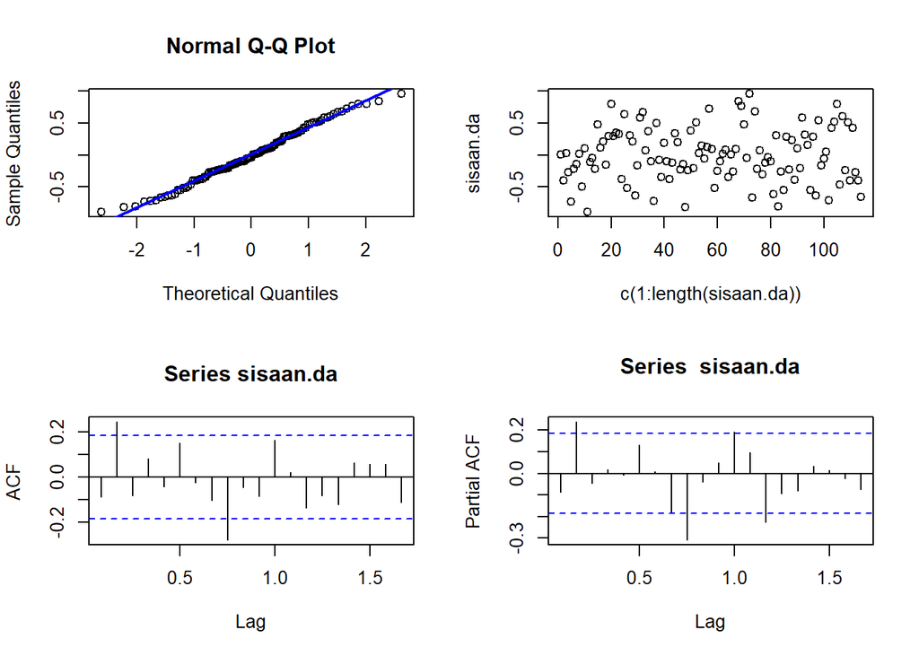

```r
#Eksplorasi
sisaan.da <- model1.da$residuals
par(mfrow=c(2,2))
qqnorm(sisaan.da)
qqline(sisaan.da, col = "blue", lwd = 2)
plot(c(1:length(sisaan.da)),sisaan.da)
acf(sisaan.da)
pacf(sisaan.da)
```

```r
par(mfrow = c(1,1))
```

### Uji Formal

```r
#1) Sisaan Menyebar Normal
ks.test(sisaan.da,"pnorm")
```

```
##
##  Asymptotic one-sample Kolmogorov-Smirnov test
##
## data:  sisaan.da
## D = 0.20812, p-value = 0.0001029
## alternative hypothesis: two-sided
```

$H_0$ : Sisaan menyebar normal

$H_1$ : Sisaan tidak menyebar normal

```r
#2) Sisaan saling bebas/tidak ada autokorelasi
Box.test(sisaan.da, type = "Ljung")
```

```
##
##  Box-Ljung test
##
## data:  sisaan.da
## X-squared = 0.89939, df = 1, p-value = 0.3429
```

$H_0$ : Sisaan saling bebas

$H_1$ : Sisaan tidak tidak saling bebas

Berdasarkan uji Ljung-Box tersebut, didapat *p-value* sebesar 0.3429 yang lebih besar dari taraf nyata 5% sehingga tak tolak $H_0$ dan menandakan bahwa sisaan saling bebas. Artinya tidak ada autokorelasi

```r
#3) Sisaan homogen
Box.test((sisaan.da)^2, type = "Ljung")
```

```
##
##  Box-Ljung test
##
## data:  (sisaan.da)^2
## X-squared = 0.030832, df = 1, p-value = 0.8606
```

$H_0$ : Ragam sisaan homogen

$H_1$ : Ragam sisaan tidak homogen

Berdasarkan uji Ljung-Box tersebut. didapat *p-value* sebesar 0.8606 yang lebih besar dari taraf nyata 5% sehingga tak tolak $H_0$ dan menandakan bahwa ragam sisaan homogen

```r
#4) Nilai tengah sisaan sama dengan nol
t.test(sisaan.da, mu = 0, conf.level = 0.95)  #tak tolak h0 > nilai tengah sisaan sama dengan 0
```

```
##
##  One Sample t-test
##
## data:  sisaan.da
## t = -0.081859, df = 113, p-value = 0.9349
## alternative hypothesis: true mean is not equal to 0
## 95 percent confidence interval:
##  -0.08041904  0.07403718
## sample estimates:
##    mean of x
## -0.003190931
```

$H_0$ : nilai tengah sisaan sama dengan 0

$H_1$ : nilai tengah sisaan tidak sama dengan 0

Berdasarkan uji-ttersebut, didapat *p-value* sebesar 0.9349 yang lebih besar dari taraf nyata 5% sehingga tak tolak $H_0$ dan menandakan bahwa nilai tengah sisaan sama dengan 0

# Overfitting

```r
model5=Arima(train.ts, order=c(3,1,2),method="ML")
summary(model5)
```

```
## Series: train.ts
## ARIMA(3,1,2)
##
## Coefficients:
##          ar1      ar2      ar3      ma1     ma2
##       0.8824  -0.8806  -0.1191  -0.9948  0.9891
## s.e.  0.0982   0.0978   0.0977   0.0255  0.0488
##
## sigma^2 = 0.1246:  log likelihood = -44.58
## AIC=101.17   AICc=101.95   BIC=117.59
##
## Training set error measures:
##                       ME      RMSE       MAE          MPE     MAPE      MASE
## Training set 0.001146799 0.3436736 0.2831459 -0.007031243 1.012301 0.5248161
##                    ACF1
## Training set 0.01873816
```

```r
lmtest::coeftest(model5)
```

```
##
## z test of coefficients:
##
##      Estimate Std. Error  z value Pr(>|z|)
## ar1  0.882439   0.098204   8.9858   <2e-16 ***
## ar2 -0.880646   0.097773  -9.0070   <2e-16 ***
## ar3 -0.119129   0.097688  -1.2195   0.2227
## ma1 -0.994757   0.025542 -38.9464   <2e-16 ***
## ma2  0.989091   0.048837  20.2531   <2e-16 ***
## ---
## Signif. codes:  0 '***' 0.001 '**' 0.01 '*' 0.05 '.' 0.1 ' ' 1
```

```r
model6=Arima(train.ts, order=c(2,1,3),method="ML")
summary(model5)
```

[output not shown]

```
## Series: train.ts
## ARIMA(3,1,2)
##
## Coefficients:
##          ar1      ar2      ar3      ma1     ma2
##       0.8824  -0.8806  -0.1191  -0.9948  0.9891
## s.e.  0.0982   0.0978   0.0977   0.0255  0.0488
##
## sigma^2 = 0.1246:  log likelihood = -44.58
## AIC=101.17   AICc=101.95   BIC=117.59
##
## Training set error measures:
##                       ME      RMSE       MAE          MPE     MAPE      MASE
## Training set 0.001146799 0.3436736 0.2831459 -0.007031243 1.012301 0.5248161
##                    ACF1
## Training set 0.01873816
```

```r
lmtest::coeftest(model5)
```

```
##
## z test of coefficients:
##
##      Estimate Std. Error  z value Pr(>|z|)
## ar1  0.882439   0.098204   8.9858   <2e-16 ***
## ar2 -0.880646   0.097773  -9.0070   <2e-16 ***
## ar3 -0.119129   0.097688  -1.2195   0.2227
## ma1 -0.994757   0.025542 -38.9464   <2e-16 ***
## ma2  0.989091   0.048837  20.2531   <2e-16 ***
## ---
## Signif. codes:  0 '***' 0.001 '**' 0.01 '*' 0.05 '.' 0.1 ' ' 1
```

# Peramalan

```r
#---FORECAST---#
ramalan <- forecast::forecast(model1.da, h = length(test))
ramalan
```

```
##        Point Forecast      Lo 80     Hi 80      Lo 95     Hi 95
## Aug 10   0.2264282549 -0.3191998 0.7720563 -0.6080378 1.0608943
## Sep 10   0.6949429967  0.1454703 1.2444157 -0.1454030 1.5352890
## Oct 10   0.4638238897 -0.1571664 1.0848142 -0.4858989 1.4135467
## Nov 10  -0.0367711262 -0.7235885 0.6500463 -1.0871677 1.0136254
## Dec 10  -0.3275166826 -1.0180148 0.3629815 -1.3835425 0.7285091
## Jan 11  -0.2630440801 -0.9649058 0.4388176 -1.3364489 0.8103607
## Feb 11  -0.0214624400 -0.7405793 0.6976544 -1.1212568 1.0783319
## Mar 11   0.1488228335 -0.5726318 0.8702775 -0.9545468 1.2521925
## Apr 11   0.1439324777 -0.5790949 0.8669598 -0.9618424 1.2497074
## May 11   0.0311984014 -0.6959730 0.7583698 -1.0809143 1.1433111
## Jun 11  -0.0643125747 -0.7923856 0.6637605 -1.1778042 1.0491790
## Jul 11  -0.0760695525 -0.8043864 0.6522473 -1.1899341 1.0377950
## Aug 11  -0.0255236450 -0.7549810 0.7039337 -1.1411325 1.0900852
## Sep 11   0.0261846534 -0.7036946 0.7560639 -1.0900693 1.1424386
## Oct 11   0.0392287817 -0.6906545 0.7691121 -1.0770314 1.1554890
## Nov 11   0.0177071353 -0.7123790 0.7477933 -1.0988632 1.1342775
## Dec 11  -0.0094290135 -0.7396121 0.7207541 -1.1261477 1.1072896
## Jan 12  -0.0194618687 -0.7496455 0.7107218 -1.1361814 1.0972576
## Feb 12  -0.0109559560 -0.7412113 0.7192993 -1.1277851 1.1058732
## Mar 12   0.0028754490 -0.7274355 0.7331864 -1.1140388 1.1197897
## Apr 12   0.0095584184 -0.7207554 0.7398723 -1.1073602 1.1264771
## May 12   0.0065957231 -0.7237201 0.7369115 -1.1103259 1.1235174
## Jun 12  -0.0002526221 -0.7305711 0.7300658 -1.1171783 1.1166731
## Jul 12  -0.0043569543 -0.7346739 0.7259600 -1.1212804 1.1125665
## Aug 12  -0.0035858859 -0.7339083 0.7267366 -1.1205177 1.1133459
## Sep 12  -0.0002972405 -0.7306274 0.7300330 -1.1172409 1.1166464
## Oct 12   0.0020887405 -0.7282437 0.7324211 -1.1148583 1.1190358
## Nov 12   0.0020815632 -0.7282497 0.7324128 -1.1148637 1.1190268
## Dec 12   0.0005556382 -0.7297741 0.7308854 -1.1163873 1.1174986
```

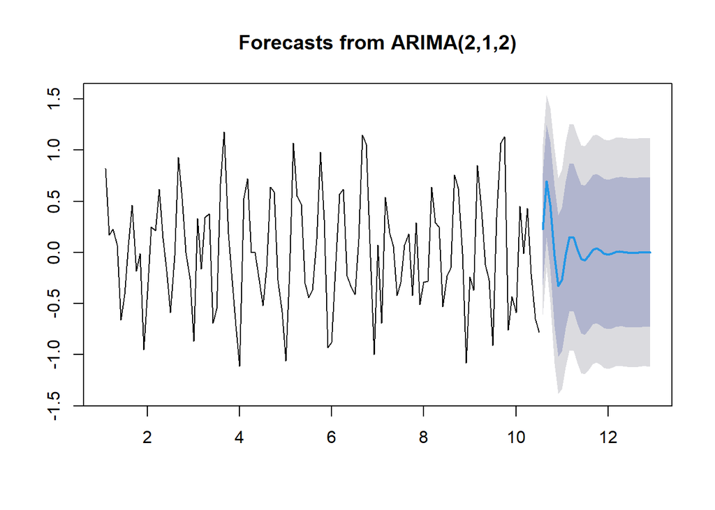

```r
data.ramalan <- ramalan$mean
plot(ramalan)
```

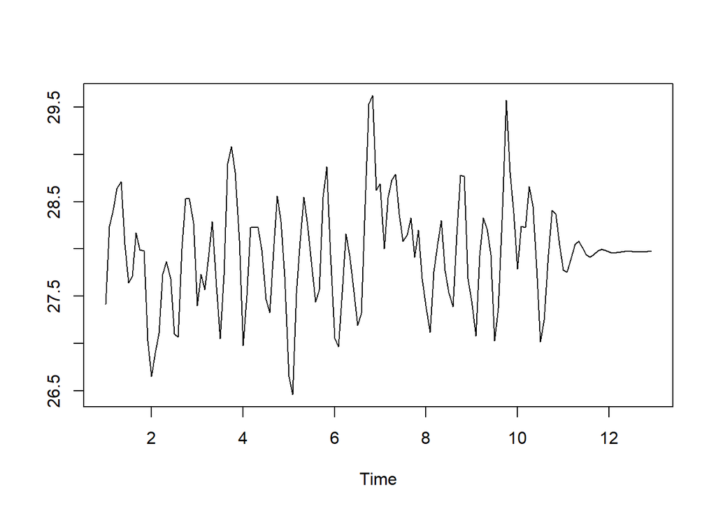

```r
pt_1 <- train.ts[115] #nilai akhir data latih
hasil.forc.Diff <- data.ramalan
hasil <- diffinv(hasil.forc.Diff, differences = 1) + pt_1
#has.1 sama hasilnta dengan: cumsum(c(pt_1,hasil.forc.Diff))
ts.plot(train.ts,hasil)
```

# AKURASI

```r
perbandingan <- matrix(data=c(head(test.ts, n=length(test)), hasil[-1]),
                     nrow = length(test), ncol = 2)
colnames(perbandingan) <- c("Aktual","Hasil Forecast")
perbandingan
```

```
##       Aktual Hasil Forecast
##  [1,]  27.06       27.24643
##  [2,]  28.40       27.94137
##  [3,]  29.77       28.40520
##  [4,]  29.69       28.36842
##  [5,]  29.01       28.04091
##  [6,]  28.06       27.77786
##  [7,]  27.80       27.75640
##  [8,]  28.21       27.90522
##  [9,]  28.56       28.04916
## [10,]  28.61       28.08035
## [11,]  28.14       28.01604
## [12,]  27.65       27.93997
## [13,]  27.75       27.91445
## [14,]  28.24       27.94063
## [15,]  28.44       27.97986
## [16,]  28.56       27.99757
## [17,]  27.58       27.98814
## [18,]  27.13       27.96868
## [19,]  26.98       27.95772
## [20,]  27.67       27.96060
## [21,]  27.97       27.97016
## [22,]  28.37       27.97675
## [23,]  28.11       27.97650
## [24,]  27.58       27.97214
## [25,]  27.83       27.96856
## [26,]  28.17       27.96826
## [27,]  28.85       27.97035
## [28,]  28.38       27.97243
## [29,]  27.90       27.97299
```

```r
accuracy(hasil[-1], head(test.ts, n=length(test)))
```

```
##                 ME      RMSE       MAE       MPE     MAPE      ACF1 Theil's U
## Test set 0.1892027 0.5722084 0.4485013 0.6298821 1.578669 0.6386853 0.9835887
```